# NYPD Shooting Report

2023-12-01

## Introduction

This report analyzes data on shooting cases of NYPD. The data was obtained directly from NYPD website.

The goal of this analysis are

1. find out any yearly trends in shooting incidents
2. any correlations between murder case and victim’s gender
3. potential biases of the provided data & this analysis

## Date Preparation

I’ll first read in the file, and then tidy the data based on the summary of the data and the goal of this analysis.

```r
# Library in packages that might need
library(tidyverse)
```

```r
library(lubridate)
library(ggplot2)
library(dplyr)
library(stats)

# read in data
ShootingData <- read_csv('https://data.cityofnewyork.us/api/views/833y-fsy8/rows.csv?accessType=DOWNLOAD')
#see the summary of the data
summary(ShootingData)
```

```
##   INCIDENT_KEY        OCCUR_DATE         OCCUR_TIME           BORO
##  Min.   :  9953245   Length:27312       Length:27312      Length:27312
##  1st Qu.: 63860880   Class :character   Class1:hms        Class :character
##  Median : 90372218   Mode  :character   Class2:difftime   Mode  :character
##  Mean   :120860536                      Mode  :numeric
##  3rd Qu.:188810230
##  Max.   :261190187
##
##  LOC_OF_OCCUR_DESC     PRECINCT      JURISDICTION_CODE LOC_CLASSFCTN_DESC
##  Length:27312       Min.   :  1.00   Min.   :0.0000    Length:27312
##  Class :character   1st Qu.: 44.00   1st Qu.:0.0000    Class :character
##  Mode  :character   Median : 68.00   Median :0.0000    Mode  :character
##                     Mean   : 65.64   Mean   :0.3269
##                     3rd Qu.: 81.00   3rd Qu.:0.0000
##                     Max.   :123.00   Max.   :2.0000
##                                      NA's   :2
##  LOCATION_DESC      STATISTICAL_MURDER_FLAG PERP_AGE_GROUP
##  Length:27312       Mode :logical           Length:27312
##  Class :character   FALSE:22046             Class :character
##  Mode  :character   TRUE :5266              Mode  :character
##
##
##
##
##    PERP_SEX          PERP_RACE         VIC_AGE_GROUP        VIC_SEX
##  Length:27312       Length:27312       Length:27312       Length:27312
##  Class :character   Class :character   Class :character   Class :character
##  Mode  :character   Mode  :character   Mode  :character   Mode  :character
##
##
##
##
##    VIC_RACE           X_COORD_CD        Y_COORD_CD        Latitude
##  Length:27312       Min.   : 914928   Min.   :125757   Min.   :40.51
##  Class :character   1st Qu.:1000028   1st Qu.:182834   1st Qu.:40.67
##  Mode  :character   Median :1007731   Median :194487   Median :40.70
##                     Mean   :1009449   Mean   :208127   Mean   :40.74
##                     3rd Qu.:1016838   3rd Qu.:239518   3rd Qu.:40.82
##                     Max.   :1066815   Max.   :271128   Max.   :40.91
##                                                        NA's   :10
##    Longitude        Lon_Lat
##  Min.   :-74.25   Length:27312
##  1st Qu.:-73.94   Class :character
##  Median :-73.92   Mode  :character
##  Mean   :-73.91
##  3rd Qu.:-73.88
##  Max.   :-73.70
##  NA's   :10
```

```r
# remove columns that not going to be used in this analysis
ShootingData <- ShootingData %>%
  select(-c(INCIDENT_KEY,LOC_OF_OCCUR_DESC,JURISDICTION_CODE,LOC_CLASSFCTN_DESC,LOCATION_DESC,PERP_AGE_GROUP,PERP_SEX,PERP_RACE,VIC_AGE_GROUP,VIC_RACE,X_COORD_CD,Y_COORD_CD,Latitude,Longitude,Lon_Lat,PRECINCT))

# convert OCCUR_DATE to date format
ShootingData$OCCUR_DATE <- as.Date(ShootingData$OCCUR_DATE, format = "%m/%d/%Y")

# Extract year and month
ShootingData$Year <- format(ShootingData$OCCUR_DATE, "%Y")
ShootingData$Month <- format(ShootingData$OCCUR_DATE, "%m")
# see the summary of the data again
summary(ShootingData)
```

```
##    OCCUR_DATE          OCCUR_TIME           BORO
##  Min.   :2006-01-01   Length:27312      Length:27312
##  1st Qu.:2009-07-18   Class1:hms        Class :character
##  Median :2013-04-29   Class2:difftime   Mode  :character
##  Mean   :2014-01-06   Mode  :numeric
##  3rd Qu.:2018-10-15
##  Max.   :2022-12-31
##  STATISTICAL_MURDER_FLAG   VIC_SEX              Year
##  Mode :logical           Length:27312       Length:27312
##  FALSE:22046             Class :character   Class :character
##  TRUE :5266              Mode  :character   Mode  :character
##
##
##
##     Month
##  Length:27312
##  Class :character
##  Mode  :character
##
##
##
```

## Visualizing Yearly Shooting Case Trends

### *Yearly Trends*

```
## `geom_line()`: Each group consists of only one observation.
## ℹ Do you need to adjust the group aesthetic?
```

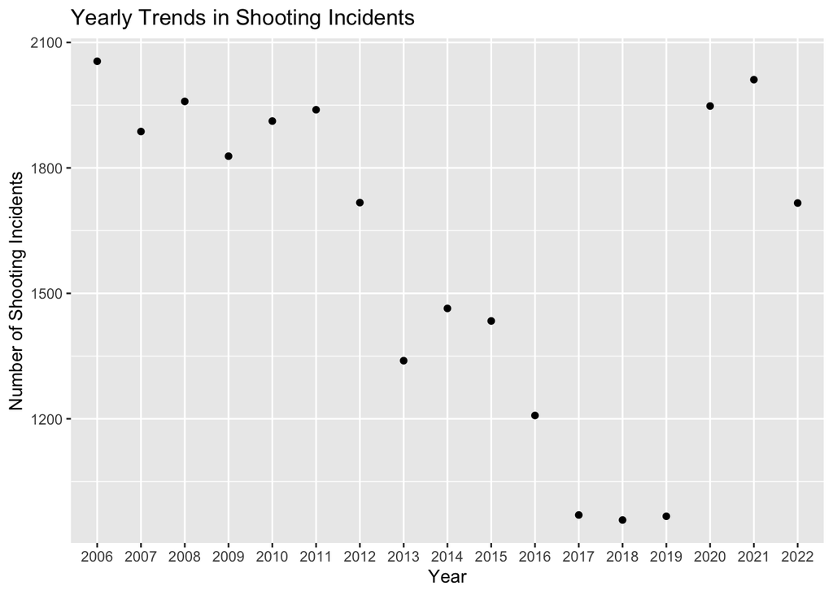

```r
# group data by year
yearly_trends <- ShootingData %>%
  group_by(Year) %>%
  summarise(Shooting_Incidents = n())

# show yearly visual
ggplot(yearly_trends, aes(x = Year, y = Shooting_Incidents)) +
  geom_line() +
  geom_point() +
  labs(title = "Yearly Trends in Shooting Incidents",
     x = "Year",
     y = "Number of Shooting Incidents")
```

### *Yearly Trends by Boro*

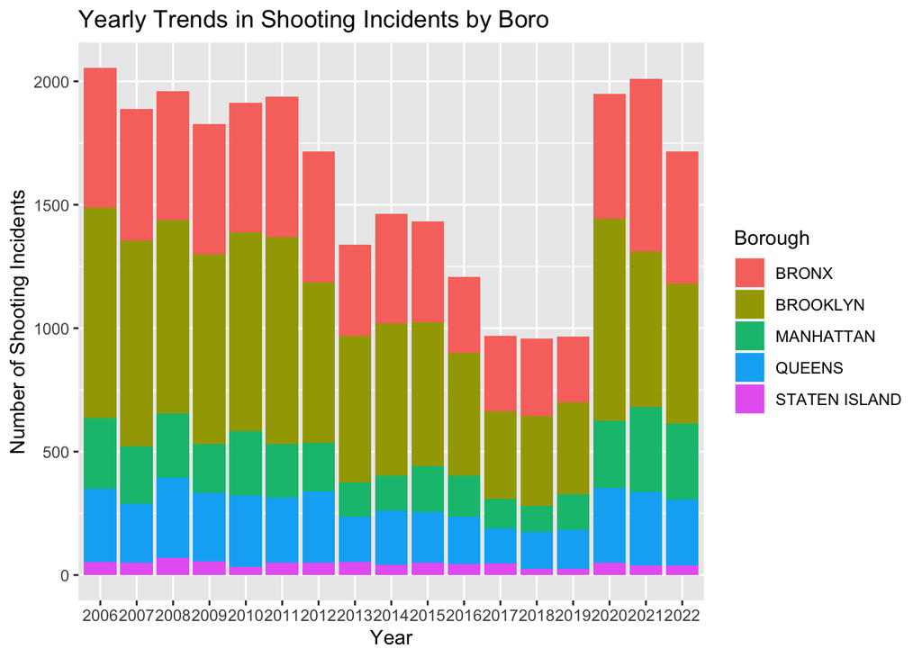

```r
# Group data by year and borough
yearly_trends_borough <- ShootingData %>%
     group_by(Year, BORO) %>%
     summarise(Shooting_Incidents = n(), .groups = 'drop')

# Plot yearly trends by borough using a stacked bar chart
ggplot(yearly_trends_borough, aes(x = Year, y = Shooting_Incidents, fill = BORO)) +
     geom_bar(stat = "identity") +
     labs(title = "Yearly Trends in Shooting Incidents by Boro",
          x = "Year",
          y = "Number of Shooting Incidents",
          fill = "Borough")
```

From the above yearly trends & distribution by boro bar chart， we can see that

1、Bronx & Brooklyn has the highest number of shooting incident occurred

2、STATEN ISLAND has the lowest number of shooting incident occurred

3、the above two finding does not mean that any boro are more dangerous or safer because population，how big the area is and other indicator has not been considered during the analysis

## Modelling Date between murder case and victim’s gender

### *Frequency analysis*

```r
# count number of murder case and non murder case and their percentages in all cases.
 murder_count = sum(ShootingData$STATISTICAL_MURDER_FLAG)
 non_murder_count <- sum(!ShootingData$STATISTICAL_MURDER_FLAG)
 murder_prop <- murder_count / nrow(ShootingData)
 non_murder_prop <- non_murder_count / nrow(ShootingData)

 #Murder Count
 print(murder_count)
```

```
## [1] 5266
```

```r
 #Non-Murder Count
 print(non_murder_count)
```

```
## [1] 22046
```

```r
 #Murder Percentage
 print(murder_prop)
```

```
## [1] 0.192809
```

### *Cross-tabulation*

```r
 cross_table <- ShootingData %>%
     group_by(VIC_SEX, STATISTICAL_MURDER_FLAG) %>%
     summarise(count = n())
print(cross_table)
```

```
## # A tibble: 6 × 3
## # Groups:   VIC_SEX [3]
##   VIC_SEX STATISTICAL_MURDER_FLAG count
##   <chr>   <lgl>                   <int>
## 1 F       FALSE                    2083
## 2 F       TRUE                      532
## 3 M       FALSE                   19953
## 4 M       TRUE                     4733
## 5 U       FALSE                      10
## 6 U       TRUE                        1
```

### *Visualization*

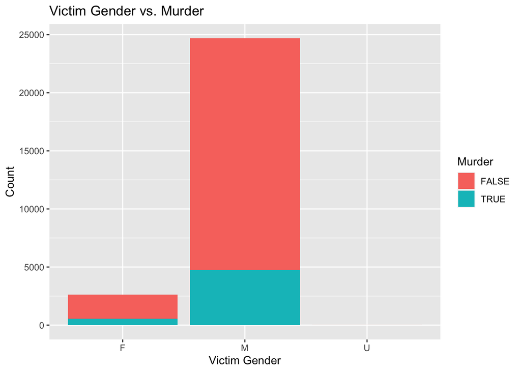

```r
ggplot(ShootingData, aes(x = VIC_SEX, fill = STATISTICAL_MURDER_FLAG, y = 1)) +
     geom_bar(stat = "identity") +
     labs(title = "Victim Gender vs. Murder", x = "Victim Gender", y = "Count", fill = "Murder")
```

### *Statistical tests*

```r
 chisq_test <- chisq.test(table(ShootingData$VIC_SEX, ShootingData$STATISTICAL_MURDER_FLAG))
 print(chisq_test)
```

```
##
##  Pearson's Chi-squared test
##
## data:  table(ShootingData$VIC_SEX, ShootingData$STATISTICAL_MURDER_FLAG)
## X-squared = 2.8188, df = 2, p-value = 0.2443
```

based on the test , X-squared = 2.8188, degree of freedom = 2 and p-value = 0.2443

the p-value of 0.2443 is greater than the typical significance level of 0,05. this is suggests that there is not enough evidence to reject the null hypotheses that **there is no statistically significant relationship between victim’s gender and murder cases in the data.**

## Potential biases of the provided data & this analysis

**Bias of the original data:**

1. if all shooting case was included in the original data, as there might be not all shooting case was reported to the police or aware by the police so might not be all cases are listed.
2. how police identify if a shooting case is a murder case is based on the the information they have and their experiences on prior cases.
3. there are missing information in the data might due to the case is still in investigation , such as we have all victim’s gender but dont have all the prep’s gender, because the nypd might havent find the prep.

**Personal Bias:**

1. as someone not familiar with New York, I might have conclusions about some boro is more dangerous than other boro just base on the number of shooting case and the murder percentage. but as i mentioned that those analysis did not consider other indicators such as population, how big of the are and other factors. it is important to understand the data and the thing the data was looking into.
2. personal experience might affect how we do the analysis ( if you are familiar with the method you gonna use or the most appropriate method) and the topic you choose to analyze.